# Week1 Homework

```
Statistics for  1001_at :
$mean
[1] 5.00846

$median
[1] 4.965856

$sd
[1] 0.3109532

$mad
[1] 0.2596079

$iqr
[1] 0.3741368

$five.num.summary
   24010    22011    20002    24022    28035
4.218220 4.803514 4.965856 5.178168 6.408157

$quantile.summary
      0%      25%      50%      75%     100%
4.218220 4.803799 4.965856 5.177936 6.408157
```

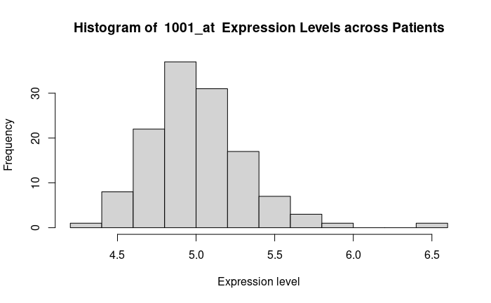

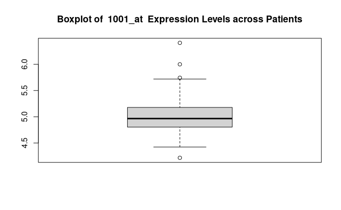

```
  The decimal point is 1 digit(s) to the left of the |

  42 | 2
  43 |
  44 | 28
  45 | 011458
  46 | 33457999
  47 | 234467899999
  48 | 000003444456777899
  49 | 000233344555666667799
  50 | 011123455666778
  51 | 2223333445588899
  52 | 1122223456689
  53 | 3368
  54 | 034466
  55 | 9
  56 | 7
  57 | 24
  58 |
  59 |
  60 | 0
  61 |
  62 |
  63 |
  64 | 1
```

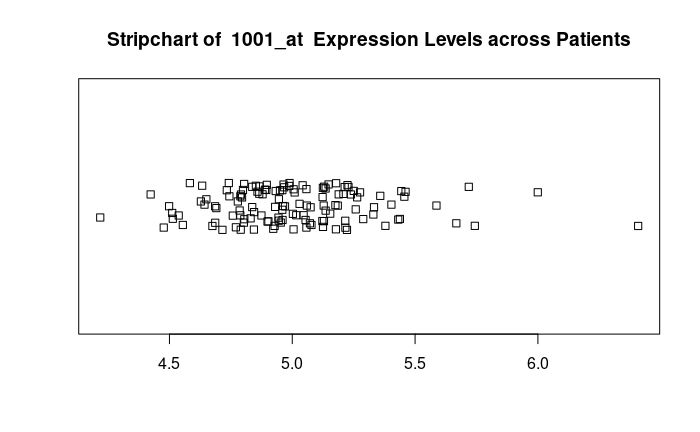

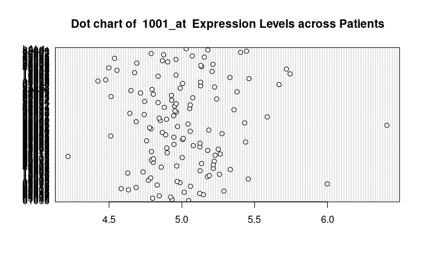

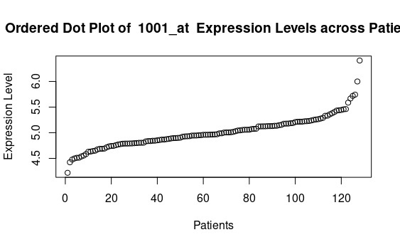

```r
stats.and.vis(lg.patients, lowest.gene)
```

```
Statistics for  1011_s_at :
$mean
[1] 6.040056

$median
[1] 6.016335

$sd
[1] 0.6393958

$mad
[1] 0.5986537

$iqr
[1] 0.7978186

$five.num.summary
   19008    12019    37013    16007    28021
4.392577 5.603642 6.016335 6.405601 7.722183

$quantile.summary
      0%      25%      50%      75%     100%
4.392577 5.607387 6.016335 6.405205 7.722183
```

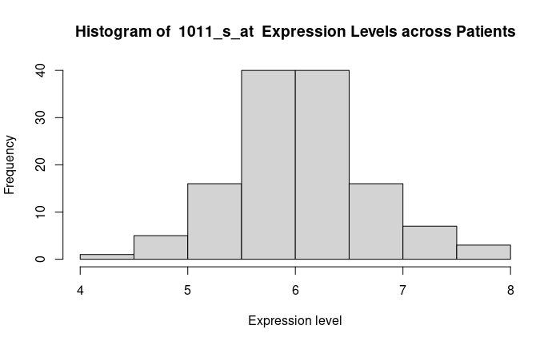

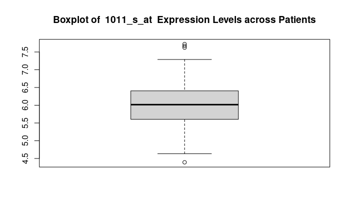

```
  The decimal point is 1 digit(s) to the left of the |

  42 | 9
  44 |
  46 | 31
  48 | 094
  50 | 581
  52 | 2555901268
  54 | 366024567789
  56 | 011690011246689
  58 | 0113356256667778
  60 | 112245578922346777
  62 | 145566801224577
  64 | 0133339467
  66 | 356782
  68 | 4889468
  70 | 6825
  72 | 459
  74 |
  76 | 272
```

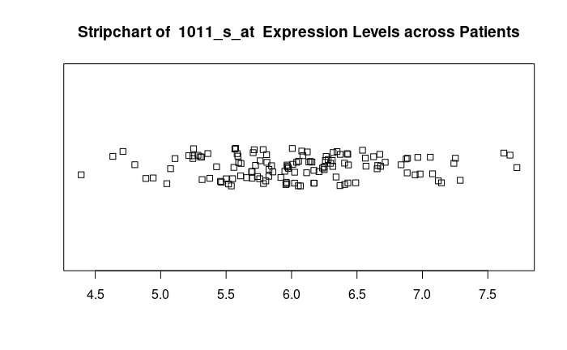

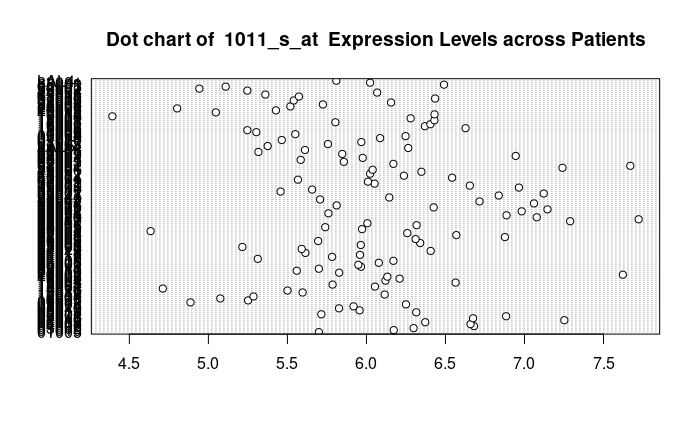

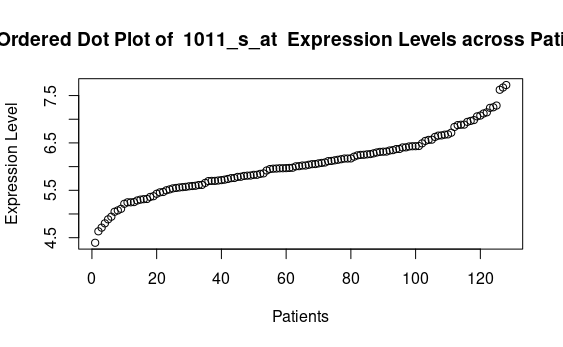

```r
stats.and.vis(hg.patients, highest.gene)
```

**f. Qualitatively compare distributions of mean gene expression levels per gene and per patient. Describe results of such comparison in plain English.**

If this analysis were to go one step further and integrate with the clinical data present in the ALL dataset, it could reveal correlations between gene expression levels and specific clinical outcomes or patient characteristics. This could help identify potential biomarkers for prognosis or targets for personalized treatment strategies in ALL patients.